Return to R Page

[figure not shown]

# $\color{darkblue}{\textbf{Super Basic}}$

### $\color{dodgerblue}{\textbf{Comments}}$

```r
# This is a comment, it won't do anything
```

### $\color{dodgerblue}{\textbf{Help}}$

Use a `?` to pull up information on a package and its arguments

```r
?round
```

### $\color{dodgerblue}{\textbf{Data Types}}$

| **Type** | **Definition** | **Example** |
| --- | --- | --- |
| Integer | number with no decimal | `100L` |
| Double | number with decimal | `100.0` |
| Character | value-less characters | `"100"` |
| Logical | binary value | `TRUE` |

`typeof()` checks the type

`as.*()` converts

- `as.integer()`
- `as.double()`
- `as.character()`
- `as.logical()`

Using a double in an operation will return a double

```r
typeof(1.0 + 1L)
```

```
[1] "double"
```

Using just integers will result in integers unless it is division

```r
typeof(1L + 1L)
```

```
[1] "integer"
```

```r
typeof(1L / 1L)
```

```
[1] "double"
```

### $\color{dodgerblue}{\textbf{Boolean Operators}}$

| **Function** | **Symbol** |
| --- | --- |
| Equal | `==` |
| Not Equal | `!=` |
| Greater Than | `>` |
| Greater Than or Equal to | `>=` |
| Less Than | `<` |
| Less Than or Equal to | `<=` |
| And | `&` |
| Or | `\|` |

### $\color{dodgerblue}{\textbf{Variables}}$

`<-` sets a variable equal to whatever you want

```r
variable <- "whatever you want"
```

Setting a variable to a variable copies the value; it is NOT a link

```r
a <- 1
b <- a

a <- 'see!'

print(str_c("a = ", a, "; b = ", b))
```

```
[1] "a = see!; b = 1"
```

### $\color{dodgerblue}{\textbf{Factors}}$

Factors turn ordinary strings into categorical variables

```r
example_strings <- c("medium", "slow", "slow", "medium", "fast")

example_strings
```

```
[1] "medium" "slow"   "slow"   "medium" "fast"
```

```r
example_factor <- factor(example_strings)

example_factor
```

```
[1] medium slow   slow   medium fast
Levels: fast medium slow
```

```r
example_ordered_factor <- factor(example_strings,
                                 ordered = TRUE,
                                 levels = c("slow","medium","fast"))

example_ordered_factor
```

```
[1] medium slow   slow   medium fast
Levels: slow < medium < fast
```

# $\color{darkblue}{\textbf{Vectors}}$

Vectors are one dimensional arrays of information:

- **Atomic Vector** = all of the same data type (logical, integer, real, complex, string)
- **Lists** (generic vectors) = the data does not need to be related at all

### $\color{dodgerblue}{\textbf{Creating}}$

`c()` creates atomic vectors

```r
eg_vector <- c(1, 2, 3)
eg_vector
```

```
[1] 1 2 3
```

`list()` creates lists

```r
eg_list <- list(1, "2", eg_vector)
eg_list
```

```
[[1]]
[1] 1

[[2]]
[1] "2"

[[3]]
[1] 1 2 3
```

#### $\color{skyblue}{\textrm{- Names}}$

`names()` adds names after creation

```r
names(eg_list) <- c("num", "char", "vec")
eg_list
```

```
$num
[1] 1

$char
[1] "2"

$vec
[1] 1 2 3
```

`=` adds names during creation

```r
list("num" = 1,
     "char" = "2",
     "vec" = eg_vector)
```

```
$num
[1] 1

$char
[1] "2"

$vec
[1] 1 2 3
```

### $\color{dodgerblue}{\textbf{Indexing}}$

#### $\color{skyblue}{\textrm{- Extract a single element}}$

`[]` extracts the entire element

```r
eg_list[1]
```

```
$num
[1] 1
```

`[[]]` extracts just the value

```r
eg_list[[1]]
```

```
[1] 1
```

#### $\color{skyblue}{\textrm{- Extract a set of elements}}$

`[c()]` extracts specific elements

```r
eg_list[c(1,3)]
```

```
$num
[1] 1

$vec
[1] 1 2 3
```

#### $\color{skyblue}{\textrm{- Extract a range of elements}}$

`[x:y]` extracts a range elements

```r
eg_list[c(1:3)]
```

```
$num
[1] 1

$char
[1] "2"

$vec
[1] 1 2 3
```

#### $\color{skyblue}{\textrm{- Extract an element by name}}$

```r
eg_list["char"]
```

```
$char
[1] "2"
```

```r
eg_list$char
```

```
[1] "2"
```

#### $\color{skyblue}{\textrm{- Extractions from nested lists}}$

`[[]][]...` extracts from within elements

```r
eg_list[[3]][2]
```

```
[1] 2
```

#### $\color{skyblue}{\textrm{- Extractions based on value}}$

```r
eg_vector[eg_vector >= 2]
```

```
[1] 2 3
```

### $\color{dodgerblue}{\textbf{Editing}}$

```r
#By Index
eg_list[1] <- 100

#By Name
eg_list["char"] <- "three"

eg_list
```

```
$num
[1] 100

$char
[1] "three"

$vec
[1] 1 2 3
```

# $\color{darkblue}{\textbf{If Statements}}$

### $\color{dodgerblue}{\textbf{Single If}}$

```r
if (condition) {
  expression
}
```

### $\color{dodgerblue}{\textbf{If/Else}}$

```r
if (condition) {
  expression_1
} else {
  expression_2
}
```

### $\color{dodgerblue}{\textbf{If and Multiple Elses}}$

```r
if (condition_1) {
  expression_1
} else if (condition_2) {
  expression_2
} else {
  expression_3
}
```

# $\color{darkblue}{\textbf{Functions}}$

### $\color{dodgerblue}{\textbf{Existing}}$

- `install.packages("package")` to install package once
- `library(package)` to load package in each script
- `update.packages("package")` to update package as needed

### $\color{dodgerblue}{\textbf{Creating}}$

#### $\color{skyblue}{\textrm{- Basic}}$

```r
function_name <- function (argument_1, argument_2) {
  expression
}
```

#### $\color{skyblue}{\textrm{- Default Values}}$

This allows for the user to add an argument, but if not, the default is used.

```r
function_name <- function (argument_1, argument_2 = default_value) {
  expression
}
```

#### $\color{skyblue}{\textrm{- Infinite Variables}}$

```r
function_name <- function(...) {
  expression using ...
}
```

#### $\color{skyblue}{\textrm{- Error Messages}}$

```r
function_name <- function(argument) {
  if (condition) {
    stop("Error message", call. = FALSE)
  }
  expression
}
```

# $\color{darkblue}{\textbf{Iterating}}$

### $\color{dodgerblue}{\textbf{Loops}}$

While these forms of iteration work, they are less preferred than mapping in R.

#### $\color{skyblue}{\textrm{- While}}$

```r
while (condition) {
  expression
}
```

```r
i <- 1

while (i <= 3) {
  print(i)

  i <- i + 1
}
```

```
[1] 1
[1] 2
[1] 3
```

#### $\color{skyblue}{\textrm{- For}}$

Iterate over a list

```r
fruit_list <- c("Apples", "Strawberries", "Bananas")

for (item in fruit_list) {
  print(str_c("I love ",item))
}
```

```
[1] "I love Apples"
[1] "I love Strawberries"
[1] "I love Bananas"
```

Iterate along a sequence

```r
for (i in seq_along(1:3)) {
  print(i + 1)
}
```

```
[1] 2
[1] 3
[1] 4
```

Fill in a New List

```r
dummy_list <- list()

for (i in seq_along(1:3)) {
  dummy_list[[i]] <- i + 1
}

dummy_list
```

```
[[1]]
[1] 2

[[2]]
[1] 3

[[3]]
[1] 4
```

### $\color{dodgerblue}{\textbf{Mapping with purrr}}$

Base R has `lapply()`, `sapply()`, and `vapply()`, but `purrr` is much better!

#### $\color{skyblue}{\textrm{- Basic}}$

`map(.x, .f, ...)` maps function `.f` over data `.x` using `...` additional arguments

- If `.x` is a dataframe, `.f` is mapped over each column
- If `.x` is a list or vector, `.f` is mapped over each item

```r
map(c(4, 16, 512), log, base = 2)
```

```
[[1]]
[1] 2

[[2]]
[1] 4

[[3]]
[1] 9
```

#### $\color{skyblue}{\textrm{- Output}}$

- `map()` returns a list
- `map_lgl()` returns a logical vector
- `map_int()` returns an integer vector
- `map_dbl()` returns a double vector
- `map_chr()` returns a character vector

```r
map(c(4, 16, 512), log, base = 2)
```

```
[[1]]
[1] 2

[[2]]
[1] 4

[[3]]
[1] 9
```

```r
map_dbl(c(4, 16, 512), log, base = 2)
```

```
[1] 2 4 9
```

```r
map_chr(c(4, 16, 512), log, base = 2)
```

```
[1] "2.000000" "4.000000" "9.000000"
```

#### $\color{skyblue}{\textrm{- On the Fly Functions}}$

`map_*(vector, ~function)` is how you apply a new function

```r
map_dbl(c(1, 2, 3), ~./.^2)
```

```
[1] 1.0000000 0.5000000 0.3333333
```

#### $\color{skyblue}{\textrm{- Preventing Errors}}$

```r
map_dbl(c(1, 10, "a"), log)
```

`Error in .Primitive("log")(x, base) : non-numeric argument to mathematical function`

`safely()` tries every element and records the result and the error message

```r
map(list(1, 10, "a"), safely(log))
```

```
[[1]]
[[1]]$result
[1] 0

[[1]]$error
NULL


[[2]]
[[2]]$result
[1] 2.302585

[[2]]$error
NULL


[[3]]
[[3]]$result
NULL

[[3]]$error
<simpleError in .Primitive("log")(x, base): non-numeric argument to mathematical function>
```

To make this workable:

```r
inputs <- list(1, 10, "a")

results <- map(inputs, safely(log))

values <- transpose(results)[["result"]]
errors <- transpose(results)[["error"]]

is_ok <- map_lgl(errors, is_null)

inputs[!is_ok]
```

```
[[1]]
[1] "a"
```

```r
errors[!is_ok]
```

```
[[1]]
<simpleError in .Primitive("log")(x, base): non-numeric argument to mathematical function>
```

`possibly()` just replaces failures with a given value

```r
map_dbl(list(1, 10, "a"), possibly(log, NA_real_))
```

```
[1] 0.000000 2.302585       NA
```

# $\color{darkblue}{\textbf{Regular Expressions}}$

### $\color{dodgerblue}{\textbf{Basics}}$

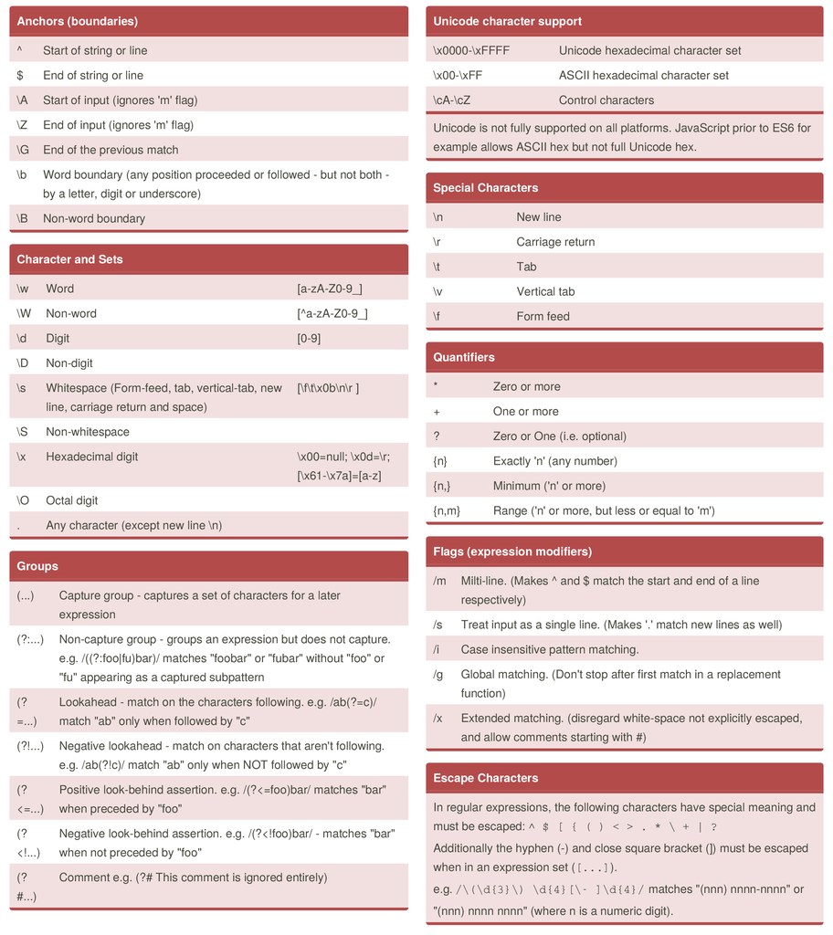

### $\color{dodgerblue}{\textbf{Testing}}$

[**regexr**](https://regexr.com/)

[figure not shown]

### $\color{dodgerblue}{\textbf{Apply}}$

#### $\color{skyblue}{\textrm{- Search}}$

- `grepl()` returns TRUE when a pattern is found in the corresponding character string.
- `grep()` returns a vector of indices of the character strings that contain the pattern.

```r
eg_text <- c("123 Main Street, Anytown, Any State, 12345, United States",
             "This is not an address",
             "567 Country Road, Notown, Any State, 54321, United States")

grepl("[0-9]+ [a-zA-Z]+ [a-zA-Z]+, [a-zA-Z]+, [a-zA-Z]+ [a-zA-Z]+, [0-9]+, United States", eg_text)
```

```
[1]  TRUE FALSE  TRUE
```

```r
grep("[0-9]+ [a-zA-Z]+ [a-zA-Z]+, [a-zA-Z]+, [a-zA-Z]+ [a-zA-Z]+, [0-9]+, United States", eg_text)
```

```
[1] 1 3
```

#### $\color{skyblue}{\textrm{- Replace}}$

- `sub()` replaces the first match
- `gsub()` replaces all matches

```r
eg_text <- "This 123 has 456 random 789 numbers"

sub("[0-9]+", "string", eg_text)
```

```
[1] "This string has 456 random 789 numbers"
```

```r
gsub("[0-9]+", "", eg_text)
```

```
[1] "This  has  random  numbers"
```